# Reproducible Research : Activity

Jose Antonio Martinez Rios

24 de octubre de 2017

## 1.- Load and preprocessing data.

In this step, download the data. Load de Library’s and look one global vision over your structure.

There are 17568 observations, without information 2304 (NA), and with activity Zero 11014, and 4250 with activity distinct from zero. Creation the one new col with the weekday.(for info)

```r
knitr::opts_chunk$set(fig.width=12, fig.height=8, fig.path='figure/',
                      echo=TRUE, warning=FALSE, message=FALSE)


# donwload data
temp <- tempfile()
download.file("https://d396qusza40orc.cloudfront.net/repdata%2Fdata%2Factivity.zip",temp,mode="wb")
data <- read.table(unz(temp, "activity.csv"),header=TRUE,sep=",",stringsAsFactors = FALSE)
unlink(temp)

# Load of library's
require(lattice)
require(lubridate)
require(dplyr)
require(chron)

# look the structure
head(data)
```

```
##   steps       date interval
## 1    NA 2012-10-01        0
## 2    NA 2012-10-01        5
## 3    NA 2012-10-01       10
## 4    NA 2012-10-01       15
## 5    NA 2012-10-01       20
## 6    NA 2012-10-01       25
```

```r
str(data)
```

```
## 'data.frame':    17568 obs. of  3 variables:
##  $ steps   : int  NA NA NA NA NA NA NA NA NA NA ...
##  $ date    : chr  "2012-10-01" "2012-10-01" "2012-10-01" "2012-10-01" ...
##  $ interval: int  0 5 10 15 20 25 30 35 40 45 ...
```

```r
dim(data)
```

```
## [1] 17568     3
```

```r
# new col with week day
data$dia <- wday(data$date,label=TRUE)

# Create subsets for data_type
noNA <- subset(data,(data$steps != "NA"))
siNA <- subset(data,(is.na(data$steps)))
dim(noNA)
```

```
## [1] 15264     4
```

```r
dim(siNA)
```

```
## [1] 2304    4
```

```r
ceros <- subset(data,(data$steps == 0))
noceros <- subset(data,(data$steps > 0))
dim(ceros)
```

```
## [1] 11014     4
```

```r
dim(noceros)
```

```
## [1] 4250    4
```

## 2.- Histogram total steps for day.

The data.frame “noceros” include the observations with steps no_Na and not cero.(4250 observations).

For the breaks the histogram (number obs two month, 60 days then choose the rule 2^k = #obs, in this case for 60 obs breaks=6.

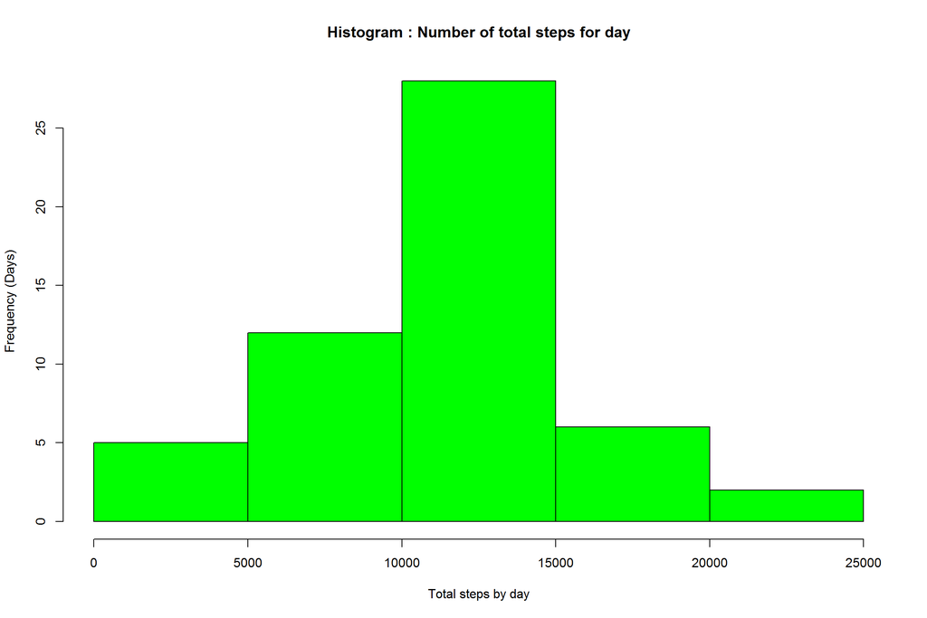

```r
data_date_group <- factor(noceros$date)
steps_by_day    <- tapply (noceros$steps, data_date_group, sum)
hist(steps_by_day, xlab="Total steps by day",ylab="Frequency (Days)",
     main="Histogram : Number of total steps for day", breaks=6,
     col="green")
```

## 3.- Calcul of the median an mean steps by day.

```r
steps_mean_day     <- aggregate(steps ~ date, data=data,mean,na.rm=TRUE)
steps_median_day   <- aggregate(steps ~ date, data= data,median,na.rm=TRUE)
steps_mean_total_day <- mean(steps_mean_day$steps)

propor_c_nc <- with(noNA,table(ifelse(noNA[,1]==0,noNA[,5] <-"C",noNA[,5] <- "NC"), date))

print(head(steps_mean_day))
```

```
##         date    steps
## 1 2012-10-02  0.43750
## 2 2012-10-03 39.41667
## 3 2012-10-04 42.06944
## 4 2012-10-05 46.15972
## 5 2012-10-06 53.54167
## 6 2012-10-07 38.24653
```

```r
print(head(steps_median_day))
```

```
##         date steps
## 1 2012-10-02     0
## 2 2012-10-03     0
## 3 2012-10-04     0
## 4 2012-10-05     0
## 5 2012-10-06     0
## 6 2012-10-07     0
```

```r
print(head(steps_mean_total_day))
```

```
## [1] 37.3826
```

## 4.- Graphic mean steps for interval.

We can to observ the low activity_mean until interval 500

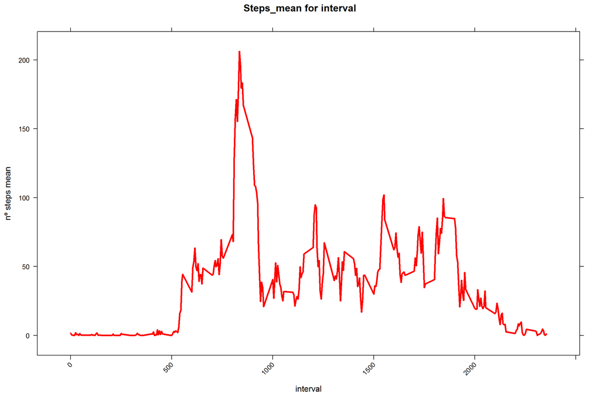

```r
# Calcul values for graphic
steps_mean_interval   <- aggregate(steps ~ interval, data,mean,na.rm=TRUE)
xyplot(steps~ interval,data=steps_mean_interval,type="l",col="red",
       main="Steps_mean for interval",ylab="nº steps mean",lwd= 3,
       scales=list(x=list(rot=45)))
```

```r
# Search the big mean-value for interval
x <- which(steps_mean_interval$steps==max(steps_mean_interval$steps))
print(steps_mean_interval[x,])
```

```
##     interval    steps
## 104      835 206.1698
```

## 5.- Strategy for imputation the NA values.

There are the differences for the mean of the days, then it is of no interest to consider this sustitution taking into account the days. Better strategy to consider the mean the intervals of each day.

The histogram is similar. The difference it’s the values in y-axis.

```r
table(siNA$dia)   # look the results
```

```
##
##   Sun   Mon  Tues   Wed Thurs   Fri   Sat
##   288   576     0   288   288   576   288
```

```r
mean_stepsintervalday   <- aggregate(steps ~ interval + dia, data,mean,na.rm=TRUE)

# sustitution the NA values for mean according interval and day
newNAvalues<- merge(x=siNA,y=mean_stepsintervalday,by.x=c("interval","dia"),
                    by.y=c("interval","dia"))

names(newNAvalues)   # look de names for creation new data.frame
```

```
## [1] "interval" "dia"      "steps.x"  "date"     "steps.y"
```

```r
newNA <- select(newNAvalues,steps.y,date,interval,dia)
names(newNA) <- names(noNA)

data_modif <- rbind(newNA,noNA)
dim(data_modif)
```

```
## [1] 17568     4
```

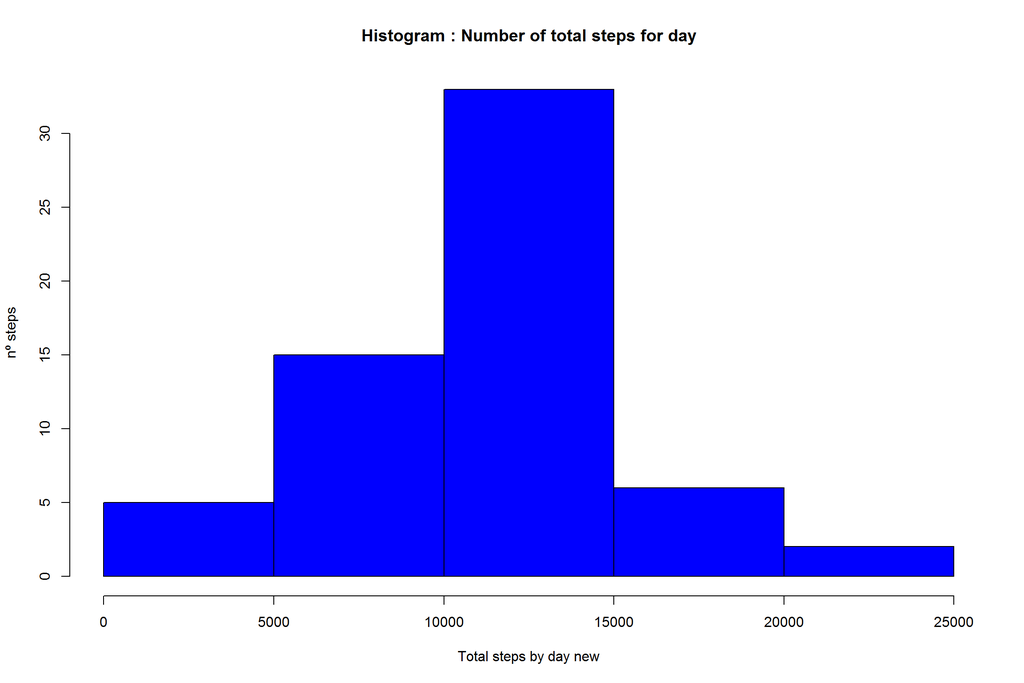

```r
# histogram
data_date_group <- factor(data_modif$date)
steps_by_day_new    <- tapply (data_modif$steps, data_date_group, sum)
hist(steps_by_day_new, xlab="Total steps by day new",ylab="nº steps",
     main="Histogram : Number of total steps for day", breaks=6,
     col="blue")
```

## 6.- Compare steps mean for week_day vs weekend.

I use the function “weekend” and then graphic in two panel

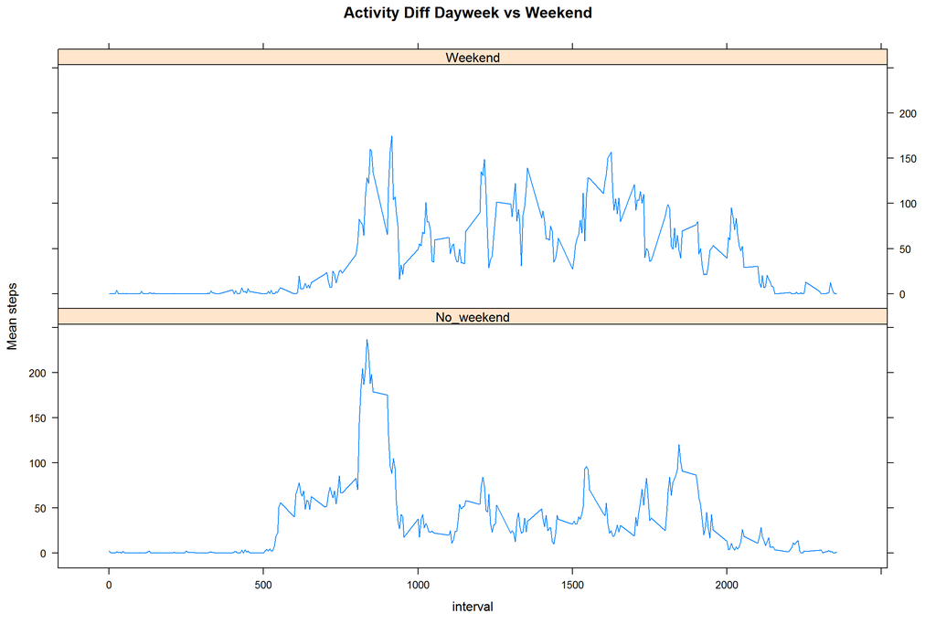

```r
data_modif$finde <- ifelse(is.weekend(data_modif$date),data_modif$finde<-"Weekend", data_modif$finde <-"No_weekend")

steps_mean_interval     <- aggregate(steps ~ interval + finde,                                       data=data_modif,mean)

week_end.f <- factor(steps_mean_interval$finde,labels=c("No_weekend","Weekend"))

xyplot(steps~interval|week_end.f, data=steps_mean_interval,type="l",
layout = c(1,2),
ylab= "Mean steps",main="Activity Diff Dayweek vs Weekend")
```